# Midterm Project

##### 5. Explore the relationship between your collapsed version of attacktype1_txt from the previous problem and the variable property, and separately the variable individual.

> Below is the Barplot in order to show the relationship between attach type and variables property and individual.

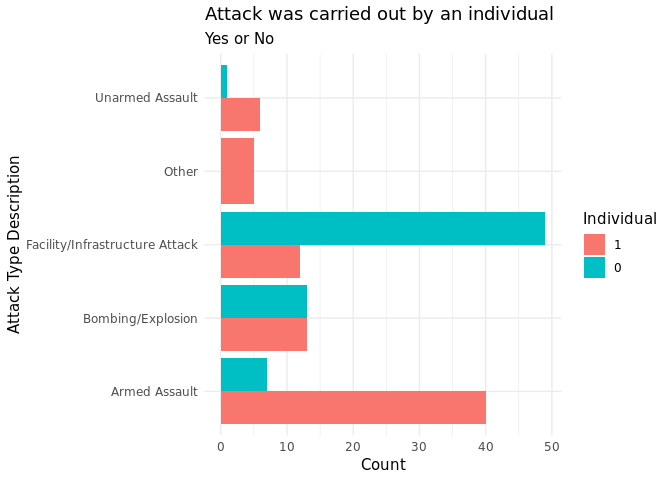

```r
finalmerge %>%
  select(property,individual, attacktype1_txt)%>%
   mutate(property = factor(property, levels = c(1, 0, -9))) %>%
   mutate(individual = factor(individual, levels = c(1, 0))) %>%
  dplyr::group_by(attacktype1_txt) %>%
  dplyr::mutate(count = n()) %>%
  mutate(attacktype1_txt= ifelse(count <= 3, 'Other', attacktype1_txt))-> newdata
#newdata$attacktype1_txt %>% table

ggplot(data = newdata, aes(x = attacktype1_txt, fill = individual))+ geom_bar(position = position_dodge()) +coord_flip()+ labs(title = "Attack was carried out by an individual", subtitle = "Yes or No", x = "Attack Type Description", y = "Count")+theme_minimal() +scale_fill_discrete(name = "Individual") + theme(panel.border = element_blank(), text=element_text(size=11.5, family="Arial light"))
```

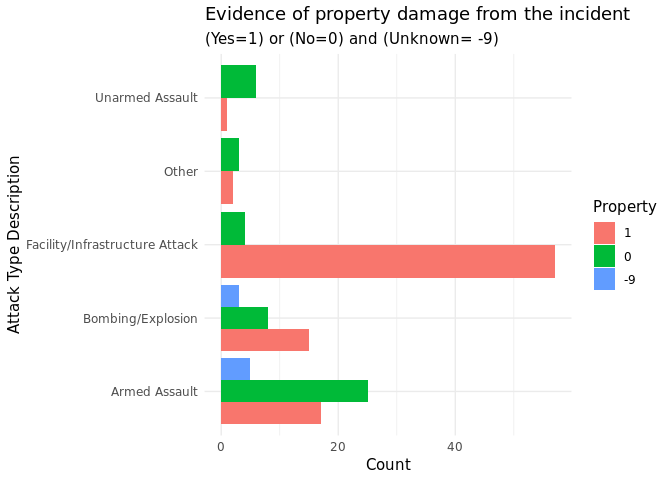

```r
ggplot(data = newdata, aes(x = attacktype1_txt, fill = property))+ geom_bar(position = position_dodge()) +coord_flip()+ labs(title = "Evidence of property damage from the incident", subtitle = "(Yes=1) or (No=0) and (Unknown= -9)", x = "Attack Type Description", y = "Count")+theme_minimal() +scale_fill_discrete(name = "Property") + theme(panel.border = element_blank(), text=element_text(size=11.5, family="Arial light"))
```

> From the above graph, we can see that the highest number of attack type are seen `Facility/Infrastructure` and property type is 1 followed by Armed Assult attack type being second on the property label 0.

> Individual value 1 means The perpetrator(s) were identified by name (or specific unnamed minors) and not known to be affiliated with a group or organization and vice-versa.

##### Writing the file in the data folder

```r
write_excel_csv(finalmerge, "data/midterm-finalmerge-annie5696.csv")
```